# HW2-part2- Feature engineering

# 5 PCA

Principal Component Analysis (PCA) transforms correlated features into smaller uncorrelated components, thereby preserving the most significant variance. PCA is applied to selected numeric variables to reduce dimensionality to improve model performance.

PC1 (Dim1) explains 32.43% of the total variance PC1 + PC2 explain 52.43% of variance, meaning they contain the majority of the information. PC1 and PC4 capture 85% of the variance. PC1(Dim1) is strongly influenced by age (34.3%), hypertension(22.4%), and glucose level (22.6%). PC3(Dim3) is influenced by hypertension (43.65%) and heart_diease (55.84%). PC2 (Dim2) is ID so should be ignored in further analysis.

```r
# create clusters with K-means
set.seed(123)
kmeans_model <- kmeans(num_vars, centers = 3) # apply k-means clustering (3 clusters)
strk$cluster <- as.factor(kmeans_model$cluster) # add cluster labels to dataset
table(strk$cluster)
```

```
   1    2    3
1671 1684 1755
```

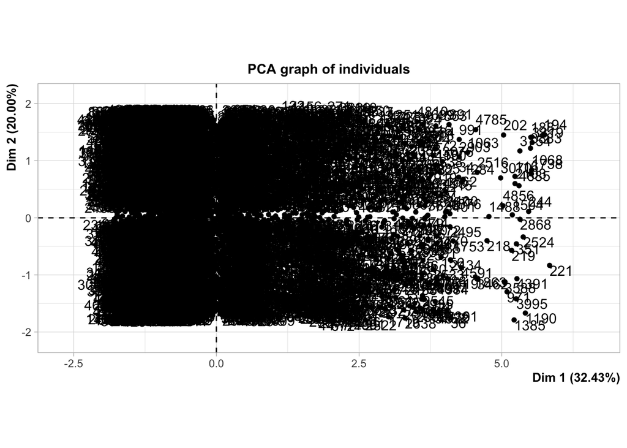

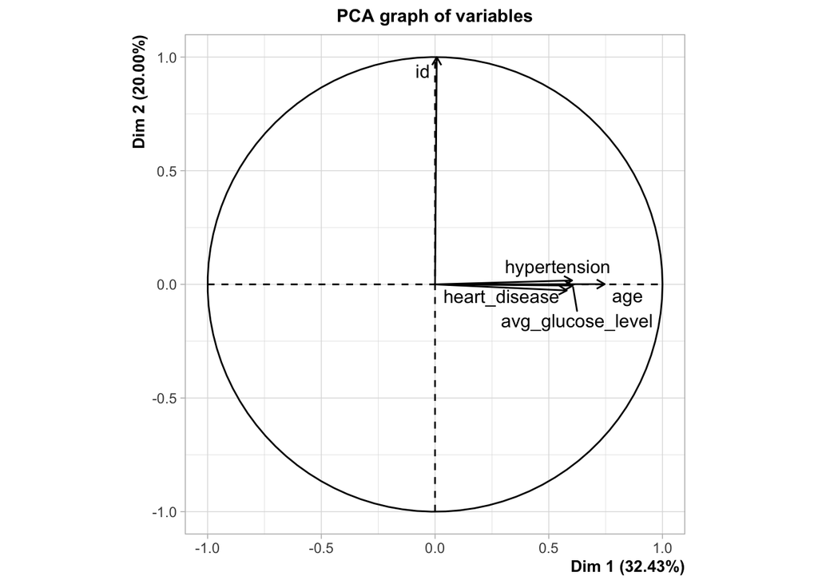

```r
# Principal component analysis (PCA)

pca_num <- PCA(num_vars, scale.unit = TRUE, ncp =5) # keep 5 components
```

```r
strk_pca <- as.data.frame(pca_num$ind$coord) # extract PCS scores

head(strk_pca)
```

```
      Dim.1      Dim.2       Dim.3     Dim.4      Dim.5
1 3.6432123 -1.4287839  3.13695321  1.187135  1.0834595
2 1.2095283  0.7064593 -0.07027685  1.864605 -0.5945141
3 2.6964943 -0.3718375  3.34472889 -1.282873  0.3009845
4 0.5756566  1.1112781 -0.01676747  1.382679 -0.2619291
5 2.9621559 -1.5933909 -2.32843364 -0.103296  0.2060486
6 1.5609002  0.9450058 -0.03617952  1.374512 -1.3302116
```

```r
summary(pca_num)
```

```
Call:
PCA(X = num_vars, scale.unit = TRUE, ncp = 5)


Eigenvalues
                       Dim.1   Dim.2   Dim.3   Dim.4   Dim.5
Variance               1.622   1.000   0.892   0.821   0.665
% of var.             32.433  20.002  17.842  16.420  13.303
Cumulative % of var.  32.433  52.434  70.277  86.697 100.000

Individuals (the 10 first)
                      Dist    Dim.1    ctr   cos2    Dim.2    ctr   cos2
1                 |  5.267 |  3.643  0.160  0.479 | -1.429  0.040  0.074 |
2                 |  2.408 |  1.210  0.018  0.252 |  0.706  0.010  0.086 |
3                 |  4.509 |  2.696  0.088  0.358 | -0.372  0.003  0.007 |
4                 |  1.883 |  0.576  0.004  0.093 |  1.111  0.024  0.348 |
5                 |  4.097 |  2.962  0.106  0.523 | -1.593  0.050  0.151 |
6                 |  2.644 |  1.561  0.029  0.349 |  0.945  0.017  0.128 |
7                 |  5.471 |  3.767  0.171  0.474 |  0.766  0.011  0.020 |
8                 |  1.747 |  0.273  0.001  0.024 | -1.229  0.030  0.495 |
9                 |  1.129 | -0.173  0.000  0.024 | -0.425  0.004  0.142 |
10                |  2.218 |  0.143  0.000  0.004 |  1.140  0.025  0.264 |
                   Dim.3    ctr   cos2
1                  3.137  0.216  0.355 |
2                 -0.070  0.000  0.001 |
3                  3.345  0.245  0.550 |
4                 -0.017  0.000  0.000 |
5                 -2.328  0.119  0.323 |
6                 -0.036  0.000  0.000 |
7                  1.200  0.032  0.048 |
8                  0.022  0.000  0.000 |
9                  0.071  0.000  0.004 |
10                 0.148  0.000  0.004 |

Variables
                     Dim.1    ctr   cos2    Dim.2    ctr   cos2    Dim.3    ctr
id                |  0.008  0.004  0.000 |  1.000 99.895  0.999 |  0.029  0.097
age               |  0.746 34.300  0.556 |  0.001  0.000  0.000 |  0.005  0.002
hypertension      |  0.603 22.390  0.363 |  0.017  0.030  0.000 | -0.624 43.651
heart_disease     |  0.579 20.685  0.335 | -0.027  0.072  0.001 |  0.706 55.845
avg_glucose_level |  0.606 22.622  0.367 | -0.005  0.003  0.000 | -0.060  0.405
                    cos2
id                 0.001 |
age                0.000 |
hypertension       0.389 |
heart_disease      0.498 |
avg_glucose_level  0.004 |
```

```r
pca_num$eig # proportion of variance explained
```

```
       eigenvalue percentage of variance cumulative percentage of variance
comp 1  1.6216273               32.43255                          32.43255
comp 2  1.0000941               20.00188                          52.43443
comp 3  0.8921135               17.84227                          70.27670
comp 4  0.8209923               16.41985                          86.69654
comp 5  0.6651728               13.30346                         100.00000
```